# Literacy Rates Around The World

AF-4

5/22/2020

## Introduction

Literacy rates of youths are a good indicator of flaws in the education system and could provide interesting conclusions when compared with other data (e.g. country GDP). Furthermore, literacy is a crucial factor in human development and economic growth, making it very important to improve our education systems.

Our data is the Youth literacy rate for 15-24 years in different countries. We analyze the youth literacy rates by regions, genders, and by economics status (Least Developed countries, etc.) The data was found on the [UNICEF Website](https://data.unicef.org/resources/dataset/education-data/). UNICEF referenced the databases from the UNESCO Institute for Statistics and Education for All Global Monitoring Report 2013/14: Teaching and Learning – Achieving Quality for All by UNESCO for their data.

## Summary Info

Our dataset displays the literacy rates of 202 countries around the world. The countries with the hightest total literacy rates were Argentina, Bahrain, Belarus, Brunei Darussalam, China, Indonesia, Italy, Kyrgyzstan, Lebanon, Portugal, Russian Federation, San Marino, Singapore, Spain. The country with the lowest total literacy rate of 38 percent was Central African Republic. The average total literacy rate was 91.1363636. Also, there were 40 countries that were considered the least developed, meaning they most likely don’t have the best access to education.

## Table

#### Introduction

The table below shows the average total literacy percentage, average female literacy percentage, and average male literacy percentage for each sub-region of Africa. This grouping calculation was performed in order to better hone in on the causes of poor literacy rates in Africa.

| Africa Sub-Region | Average Overall Percentage | Female Percentage | Male Percentage |
| --- | --- | --- | --- |
| Eastern Africa | 59.57143 | 59.85714 | 59.57143 |
| Central Africa | 43.66667 | 42.11111 | 45.22222 |
| Northern Africa | 32.50000 | 32.33333 | 32.66667 |
| Western Africa | 30.73333 | 28.40000 | 33.33333 |
| Southern Africa | 28.20000 | 28.50000 | 28.10000 |

#### Interpretation of Table

According to the table, the sub-region with the lowest overall literacy rate is Southern Africa and the sub-region with the highest overall literacy rate is Eastern Africa. The region with the lowest female literacy rate is Western Africa, and the region with the lowest male literacy rate is Southern Africa.

## Charts

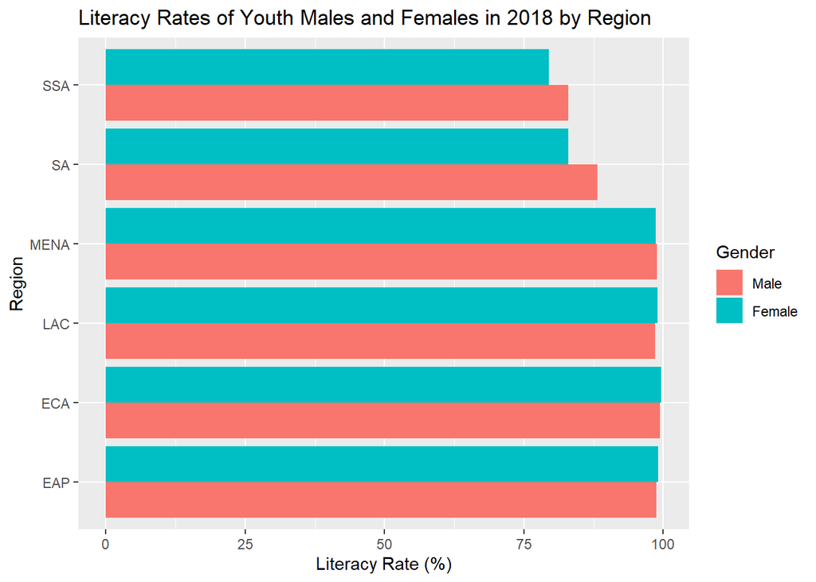

#### Analysis and Insights

We plot the chart to explore the difference of literacy rate across gender (male and female) grouped by regions of the world. The data is grouped by the region and plotted by the average literacy rate of males and females in each group. The bar plot with two percentages of each gender would allow us to compare the differences across gender and region.

Analyzing the different percentage of males and females between two groups:

- Lower Literacy rate (the first two regions): the literacy rate of female is lesser than male
- Higher Literacy rate (the last four regions): the literacy rate of female tends to higher than of male (3 out of 4 regions)

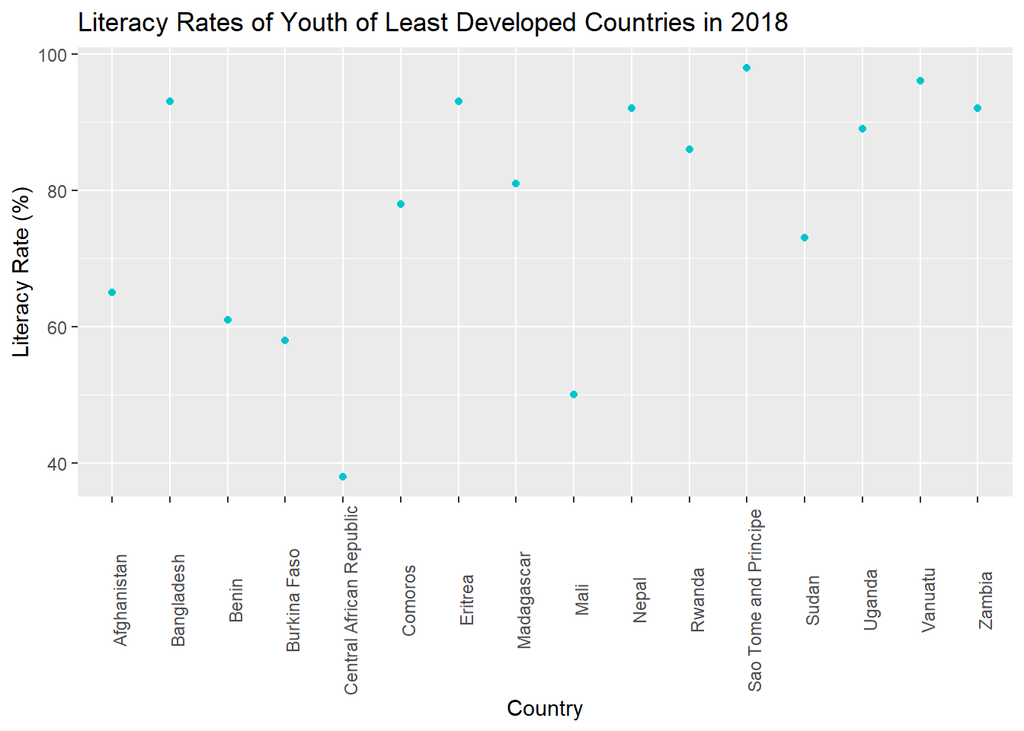

#### Analysis and Insights

In this chart, we wanted to see if there was a similar relationship between the least developing countries (LDC) and their overall youth literacy rates. We thought it’d be best to plot this on a scatter plot so we could clearly interpret whether the literacy rates of the youth were generally high or low.

#### Literacy Rate of Youth By Location

[interactive chart not shown]

#### Analysis and Insights

We want to know if the high or low literacy rate countries are clustered by their locations. Therefore, we have visualizations on the world map with the literacy rate of each country represented by a circle whose radius is one’s literacy rate relatively with others.